# Are MN Nordic Ski Sections Unfair?

Karl Holub karljholub@gmail.com

# About

The MSHSL splits high schools into “sections” roughly corresponding to co-location. For the biggest race of the year, the state meet, a select number of skiers, 20 per section across 8 sections, are invited to the state meet. State qualifiers are determined at an annual Sections meet. Qualifiers are comprised of two teams of 7 skiers, and 6 individuals. Teams are scored by their top 4 skiers (why 7 are brought to the state meet is… irrational, but a topic for another day), and the two teams with the highest scores qualify all 7 team members. Substracting these 14 skiers, the next best 6 individual skiers (from any team) are qualified.

Skiers work hard to qualify for the state meet. Do some skiers have an easier path to the state meet than others, due simply to their section assignment (geographic location)? Life usually isn’t fair, let’s prove it!

## Data

I pulled [2020 state meet data](https://www.skinnyski.com/racing/highschool/2020/statemeet-expanded.pdf) from SkinnySki.com, and [sections data](https://old.mshsl.org/sections/list.asp) from the MSHSL.

Here’s the data:

```r
girls
```

| PLACE | BIB | NAME | GRADE | TEAM | FREESTYLE | F.PLC | CLASSIC | C.PLC | PURSUIT | SCORE | TIME.BACK | MOVE |
| --- | --- | --- | --- | --- | --- | --- | --- | --- | --- | --- | --- | --- |
| 1 | 2 | Molly Moening | 10 | St Paul Highland Park | 0:16:15 | 2 | 0:16:01 | 1 | 0:32:16 | 112 |  | 1 |
| 2 | 1 | Elizabeth Tuttle | 12 | Stillwater | 0:16:03 | 1 | 0:17:06 | 5 | 0:33:09 | 111 | 00:52.4 | -1 |
| 3 | 3 | Jordan Parent | 9 | Forest Lake | 0:16:43 | 3 | 0:16:41 | 2 | 0:33:24 | 110 | 01:07.8 | 0 |
| 4 | 4 | Lauren McCollor | 11 | Wayzata | 0:16:54 | 4 | 0:17:02 | 4 | 0:33:56 | 109 | 01:40.3 | 0 |
| 5 | 8 | Margo Nightingale | 9 | Mounds Park Academy | 0:17:13 | 8 | 0:16:46 | 3 | 0:33:59 | NA | 01:43.3 | 3 |
| 6 | 5 | Morgan Richter | 12 | Edina | 0:16:57 | 5 | 0:17:06 | 6 | 0:34:03 | 108 | 01:47.0 | -1 |
| 7 | 7 | Brianne Brewster | 12 | Lakeville | 0:17:01 | 7 | 0:17:16 | 9 | 0:34:17 | NA | 02:01.1 | 0 |
| 8 | 12 | Amelea Hauer | 11 | Forest Lake | 0:17:28 | 12 | 0:17:10 | 7 | 0:34:38 | 107 | 02:21.4 | 4 |
| 9 | 6 | Christina Bolcer | 12 | Maple Grove | 0:16:57 | 6 | 0:17:46 | 16 | 0:34:43 | 106 | 02:26.5 | -3 |
| 10 | 9 | Maggie Wagner | 10 | Edina | 0:17:15 | 9 | 0:17:28 | 10 | 0:34:43 | 105 | 02:26.8 | -1 |

[output cut: 149 more lines]

```r
boys
```

| PLACE | BIB | NAME | GRADE | TEAM | FREESTYLE | F.PLC | CLASSIC | C.PLC | PURSUIT | SCORE | TIME.BACK | MOVE |
| --- | --- | --- | --- | --- | --- | --- | --- | --- | --- | --- | --- | --- |
| 1 | 204 | Henry Snider | 12 | Mounds Park Academy | 0:14:10 | 4 | 0:14:14 | 1 | 0:28:24 | NA |  | 3 |
| 2 | 201 | Roger Anderson | 11 | Robinsdale Armstrong | 0:13:58 | 1 | 0:14:27 | 2 | 0:28:25 | 112 | 00:00.6 | -1 |
| 3 | 202 | Clark Young | 12 | Maple Grove | 0:14:06 | 2 | 0:14:51 | 10 | 0:28:57 | 111 | 00:32.7 | -1 |
| 4 | 206 | Jasper Johnston | 11 | Ely | 0:14:14 | 6 | 0:14:48 | 7 | 0:29:02 | 110 | 00:37.9 | 2 |
| 5 | 203 | Colin Freed | 11 | Wayzata | 0:14:07 | 3 | 0:14:56 | 14 | 0:29:03 | 109 | 00:38.8 | -2 |
| 6 | 211 | Noah Erickson | 10 | Forest Lake | 0:14:35 | 11 | 0:14:30 | 3 | 0:29:05 | 108 | 00:40.9 | 5 |
| 7 | 209 | Cooper Lennox | 12 | Mora | 0:14:25 | 9 | 0:14:46 | 6 | 0:29:11 | NA | 00:46.7 | 2 |
| 8 | 205 | Zachary Nemeth | 12 | Sartell - St. Cloud Cathedral | 0:14:12 | 5 | 0:15:06 | 16 | 0:29:18 | 107 | 00:53.9 | -3 |
| 9 | 207 | William Nemeth | 12 | Sartell - St. Cloud Cathedral | 0:14:23 | 7 | 0:14:55 | 13 | 0:29:18 | 106 | 00:54.2 | -2 |
| 10 | 210 | Jackson Grant | 11 | Little Falls | 0:14:29 | 10 | 0:14:52 | 11 | 0:29:21 | 105 | 00:57.0 | 0 |

[output cut: 146 more lines]

```r
sections
```

| section | school |
| --- | --- |
| 1 | Burnsville |
| 1 | Rosemount |
| 1 | Eastview |
| 1 | Apple Valley |
| 1 | Eagan |
| 1 | Hastings |
| 1 | Lakeville |
| 1 | New Prague |
| 1 | Northfield |
| 1 | Prior Lake |

[output cut: 106 more lines]

To demonstrate that every skier is assigned a section:

```r
anti_join(boys, sections, by=c('TEAM' = 'school')) %>%
  select(TEAM) %>%
  unique()
```

| TEAM |
| --- |

```r
anti_join(girls, sections, by=c('TEAM' = 'school')) %>%
  select(TEAM) %>%
  unique()
```

| TEAM |
| --- |

## State Meet Placement by Section

Now we run some quick stats on the state meet finishing place of skiers in each section:

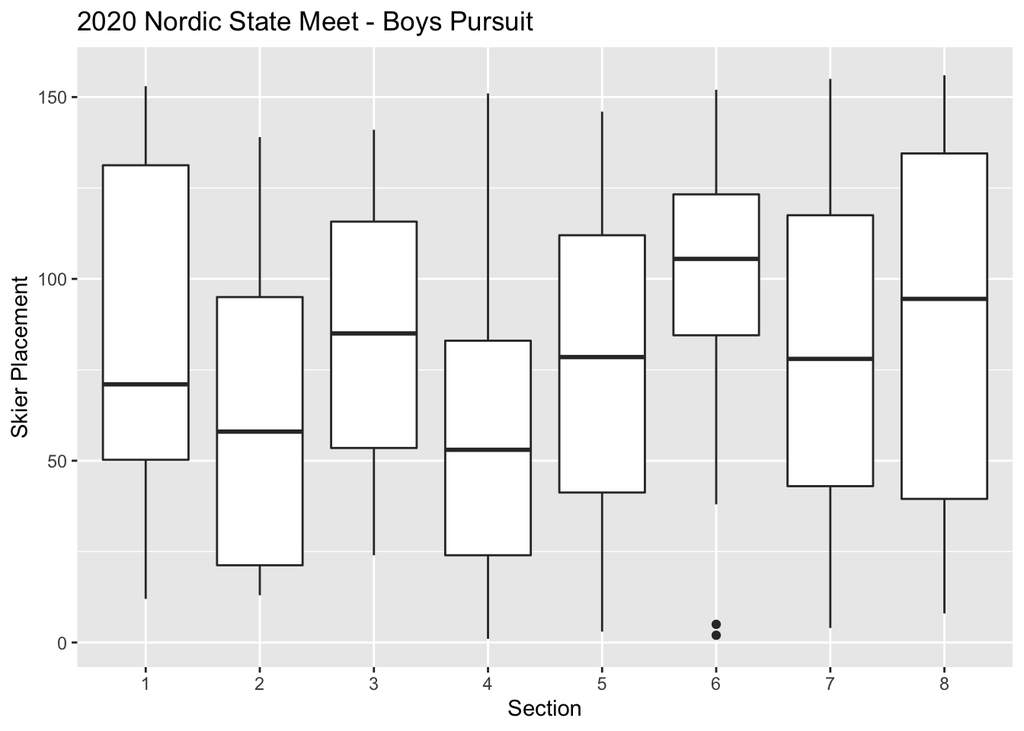

```r
section_boys <- inner_join(boys, sections, by=c('TEAM' = 'school'))
section_girls <- inner_join(girls, sections, by=c('TEAM' = 'school'))

ggplot(section_boys) +
  geom_boxplot(aes(as.factor(section), PLACE)) +
  xlab('Section') +
  ylab('Skier Placement') +
  ggtitle('2020 Nordic State Meet - Boys Pursuit')
```

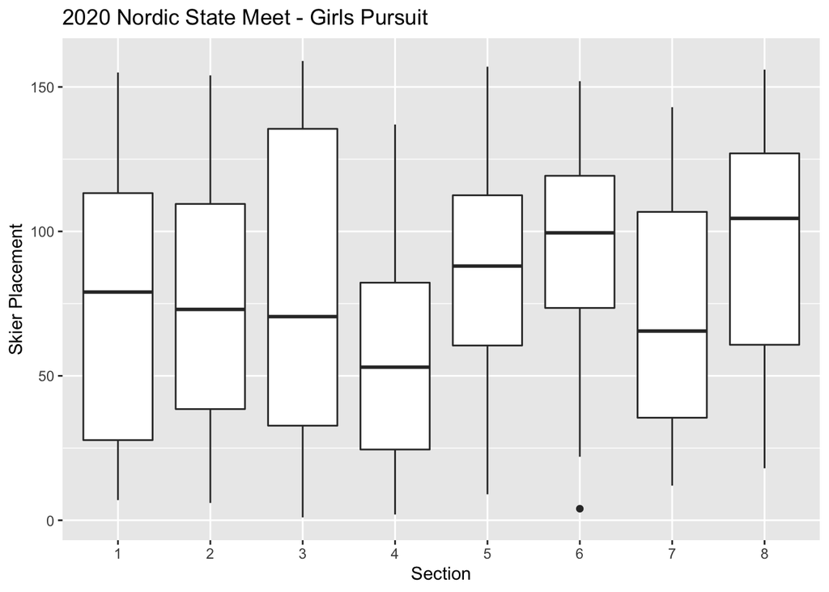

```r
ggplot(section_girls) +
  geom_boxplot(aes(as.factor(section), PLACE)) +
  xlab('Section') +
  ylab('Skier Placement') +
  ggtitle('2020 Nordic State Meet - Girls Pursuit')
```

Below is a table of average ranks among all qualifiers from a section, and the average among the most competitive (top half) qualifiers from a section. Approximately the same story holds.

```r
top_half_mean <- function(v) {
  sorted_v <- sort(v)
  mean(v[1:(length(v)/2)])
}

section_boys %>%
  group_by(section) %>%
  summarize(
    racers = n(),
    average_rank = mean(PLACE),
    top_half_rank = top_half_mean(PLACE)
  )
```

| section | racers | average_rank | top_half_rank |
| --- | --- | --- | --- |
| 1 | 20 | 82.75000 | 46.40000 |
| 2 | 20 | 60.90000 | 29.30000 |
| 3 | 18 | 83.38889 | 53.22222 |
| 4 | 19 | 59.57895 | 20.00000 |
| 5 | 20 | 78.00000 | 41.90000 |
| 6 | 20 | 96.35000 | 64.90000 |
| 7 | 19 | 78.05263 | 38.22222 |
| 8 | 20 | 88.50000 | 43.20000 |

```r
section_girls %>%
  group_by(section) %>%
  summarize(
    racers = n(),
    average_rank = mean(PLACE),
    top_half_rank = top_half_mean(PLACE)
  )
```

| section | racers | average_rank | top_half_rank |
| --- | --- | --- | --- |
| 1 | 20 | 74.55000 | 32.50000 |
| 2 | 19 | 71.73684 | 30.22222 |
| 3 | 20 | 84.80000 | 34.90000 |
| 4 | 20 | 58.80000 | 23.10000 |
| 5 | 20 | 89.15000 | 57.10000 |
| 6 | 20 | 93.65000 | 60.10000 |
| 7 | 20 | 71.30000 | 36.50000 |
| 8 | 20 | 95.60000 | 61.70000 |